# Basic Data Preprocessing with Numpy, Pandas, and Matplotlib

## Michael Rawat

The codes in this notebook closely follows the original notebook prepared by previous instructors of BIA 6303-Predictive Models: Myles Gartland, Harlan Hays, Xuan Pham.

First, let's import our packages.

```python
#import packages
%matplotlib inline
import numpy as np
import matplotlib.pyplot as plt
import pandas as pd
```

Next, let's check our working directory.

```python
%pwd
```

```
'C:\\Users\\micha\\OneDrive\\Desktop\\Rockhurst University\\Classes\\BIA 6303 - Predictive Models\\Module1\\code'
```

Now I am going to change my directory to show the "data" folder. This is not necessary if your data set is in one folder.

```python
cd C:\\Users\\micha\\OneDrive\\Desktop\\Rockhurst University\\Classes\\BIA 6303 - Predictive Models\\Module1\\data
```

```
C:\Users\micha\OneDrive\Desktop\Rockhurst University\Classes\BIA 6303 - Predictive Models\Module1\data
```

Now I am going to import the data set as a pandas array (similar to a dataframe in R) from the "data" folder.

```python
#import Using Pandas
video_pandas=pd.read_csv("Video_Store.csv")
video_pandas
```

|  | Cust ID | Gender | Income | Age | Rentals | Avg Per Visit | Incidentals | Genre |
| --- | --- | --- | --- | --- | --- | --- | --- | --- |
| 0 | 1 | M | 45000 | 25 | 32 | 2.5 | Yes | Action |
| 1 | 2 | F | 54000 | 33 | 12 | 3.4 | No | Drama |
| 2 | 3 | F | 32000 | 20 | 42 | 1.6 | No | Comedy |
| 3 | 4 | F | 59000 | 70 | 16 | 4.2 | Yes | Drama |
| 4 | 5 | M | 37000 | 35 | 25 | 3.2 | Yes | Action |
| 5 | 6 | M | 18000 | 20 | 29 | 1.7 | No | Action |
| 6 | 7 | F | 29000 | 45 | 19 | 3.8 | No | Drama |
| 7 | 8 | M | 74000 | 25 | 31 | 2.4 | Yes | Action |
| 8 | 9 | M | 38000 | 21 | 18 | 2.1 | No | Comedy |
| 9 | 10 | F | 65000 | 40 | 21 | 3.3 | No | Drama |
| 10 | 11 | F | 41000 | 22 | 48 | 2.3 | Yes | Drama |
| 11 | 12 | F | 26000 | 22 | 32 | 2.9 | Yes | Action |
| 12 | 13 | M | 83000 | 46 | 14 | 3.6 | No | Comedy |
| 13 | 14 | M | 45000 | 36 | 24 | 2.7 | No | Drama |
| 14 | 15 | M | 68000 | 30 | 36 | 2.7 | Yes | Comedy |
| 15 | 16 | M | 17000 | 19 | 26 | 2.2 | Yes | Action |
| 16 | 17 | M | 36000 | 35 | 28 | 3.5 | Yes | Drama |
| 17 | 18 | F | 6000 | 16 | 39 | 1.8 | Yes | Action |
| 18 | 19 | F | 24000 | 25 | 41 | 3.1 | No | Comedy |
| 19 | 20 | M | 12000 | 16 | 23 | 2.2 | Yes | Action |
| 20 | 21 | F | 47000 | 52 | 11 | 3.1 | No | Drama |
| 21 | 22 | M | 25000 | 33 | 16 | 2.9 | Yes | Drama |
| 22 | 23 | F | 2000 | 15 | 30 | 2.5 | No | Comedy |
| 23 | 24 | F | 79000 | 35 | 22 | 3.8 | Yes | Drama |
| 24 | 25 | M | 1000 | 16 | 25 | 1.4 | Yes | Comedy |
| 25 | 26 | F | 56000 | 35 | 40 | 2.6 | Yes | Action |
| 26 | 27 | F | 62000 | 47 | 32 | 3.6 | No | Drama |
| 27 | 28 | M | 57000 | 52 | 22 | 4.1 | No | Comedy |
| 28 | 29 | F | 15000 | 18 | 37 | 2.1 | Yes | Action |
| 29 | 30 | M | 41000 | 25 | 17 | 1.4 | Yes | Action |
| 30 | 31 | F | 49000 | 56 | 15 | 3.2 | No | Comedy |
| 31 | 32 | M | 47000 | 30 | 21 | 3.1 | Yes | Drama |
| 32 | 33 | M | 23000 | 25 | 28 | 2.7 | No | Action |
| 33 | 34 | F | 29000 | 32 | 19 | 2.9 | Yes | Action |
| 34 | 35 | M | 74000 | 29 | 43 | 4.6 | Yes | Action |
| 35 | 36 | F | 29000 | 21 | 34 | 2.3 | No | Comedy |
| 36 | 37 | M | 89000 | 46 | 12 | 1.2 | No | Comedy |
| 37 | 38 | M | 41000 | 38 | 20 | 3.3 | Yes | Drama |
| 38 | 39 | F | 68000 | 35 | 19 | 3.9 | No | Comedy |
| 39 | 40 | M | 17000 | 19 | 32 | 1.8 | No | Action |
| 40 | 41 | F | 50000 | 33 | 17 | 1.4 | No | Drama |
| 41 | 42 | M | 32000 | 25 | 26 | 2.2 | Yes | Action |
| 42 | 43 | F | 49000 | 28 | 48 | 3.3 | Yes | Drama |
| 43 | 44 | M | 35000 | 24 | 24 | 1.7 | No | Drama |
| 44 | 45 | M | 56000 | 38 | 30 | 3.5 | Yes | Drama |
| 45 | 46 | F | 57000 | 43 | 9 | 1.1 | No | Drama |
| 46 | 47 | F | 69000 | 35 | 22 | 2.8 | Yes | Drama |
| 47 | 48 | F | 52000 | 47 | 14 | 1.6 | No | Drama |
| 48 | 49 | M | 31000 | 25 | 42 | 3.4 | Yes | Action |
| 49 | 50 | M | 24000 | 20 | 33 | 4.7 | No | Action |

Okay, that was a really big and ugly output. Can we do better? We know from R that we can use the head() and tail() function to preview the structure of a data frame. How can we deploy something similar in Python? Python uses the structure of dataframe.variable.function(). Let's see how this look in Python.

```python
video_pandas.head()
```

|  | Cust ID | Gender | Income | Age | Rentals | Avg Per Visit | Incidentals | Genre |
| --- | --- | --- | --- | --- | --- | --- | --- | --- |
| 0 | 1 | M | 45000 | 25 | 32 | 2.5 | Yes | Action |
| 1 | 2 | F | 54000 | 33 | 12 | 3.4 | No | Drama |
| 2 | 3 | F | 32000 | 20 | 42 | 1.6 | No | Comedy |
| 3 | 4 | F | 59000 | 70 | 16 | 4.2 | Yes | Drama |
| 4 | 5 | M | 37000 | 35 | 25 | 3.2 | Yes | Action |

```python
video_pandas.tail()
```

|  | Cust ID | Gender | Income | Age | Rentals | Avg Per Visit | Incidentals | Genre |
| --- | --- | --- | --- | --- | --- | --- | --- | --- |
| 45 | 46 | F | 57000 | 43 | 9 | 1.1 | No | Drama |
| 46 | 47 | F | 69000 | 35 | 22 | 2.8 | Yes | Drama |
| 47 | 48 | F | 52000 | 47 | 14 | 1.6 | No | Drama |
| 48 | 49 | M | 31000 | 25 | 42 | 3.4 | Yes | Action |
| 49 | 50 | M | 24000 | 20 | 33 | 4.7 | No | Action |

Can we view the data structure too? Yes, we can. Let's look at two ways of doing it.

```python
video_pandas.describe() #similar to str() in R
```

|  | Cust ID | Income | Age | Rentals | Avg Per Visit |
| --- | --- | --- | --- | --- | --- |
| count | 50.00000 | 50.000000 | 50.000000 | 50.000000 | 50.000000 |
| mean | 25.50000 | 42300.000000 | 31.560000 | 26.320000 | 2.748000 |
| std | 14.57738 | 21409.753642 | 12.000272 | 10.047723 | 0.898125 |
| min | 1.00000 | 1000.000000 | 15.000000 | 9.000000 | 1.100000 |
| 25% | 13.25000 | 26750.000000 | 22.000000 | 19.000000 | 2.125000 |
| 50% | 25.50000 | 41000.000000 | 30.000000 | 25.000000 | 2.750000 |
| 75% | 37.75000 | 56750.000000 | 37.500000 | 32.000000 | 3.375000 |
| max | 50.00000 | 89000.000000 | 70.000000 | 48.000000 | 4.700000 |

```python
video_pandas.shape
```

```
(50, 8)
```

Wait, what just happened? Why did we leave out the parentheses in the "shape" function? The answer is because Python is a general programming language. Programming languages have methods (actions) and attributes (characteristics). Many programming languages use parentheses to denote methods. The programmers of pandas have decided that describe is an action (hence, a method) but shape is a characteristic of a dataset (hence, an attribute). For more on this, check out this 1 minute video: https://youtu.be/hSrDViyKWVk.

Okay, let's explore video_pandas further.

```python
#mean of dataframe
video_pandas.mean()

# To avoid warning you can specify the columns you want to observe
#print("Mean of Cust ID: ",video_pandas['Cust ID'].mean())
#print("Mean of Income: ",video_pandas['Income'].mean())
#print("Mean of Age: ",video_pandas['Age'].mean())
#print("Mean of Rentals: ",video_pandas['Rentals'].mean())
#print("Mean of Avg Per Visit: ",video_pandas['Avg Per Visit'].mean())
```

```
Cust ID             25.500
Income           42300.000
Age                 31.560
Rentals             26.320
Avg Per Visit        2.748
dtype: float64
```

```python
#show variables by type
video_pandas.dtypes
```

```
Cust ID            int64
Gender            object
Income             int64
Age                int64
Rentals            int64
Avg Per Visit    float64
Incidentals       object
Genre             object
dtype: object
```

```python
#descriptive statistics for Income
print(video_pandas.Income.min()),
print(video_pandas.Income.max()),
print(video_pandas.Income.std()),
print(video_pandas.Income.mean())
```

```
1000
89000
21409.753642216627
42300.0
```

```python
#descriptive statistics for Age variable
print(video_pandas.Age.min(),video_pandas.Age.max(),video_pandas.Age.std(),video_pandas.Age.mean())
```

```
15 70 12.000272105758475 31.56
```

```python
#all the descriptive/summary statistics for Rentals variable
video_pandas.Rentals.describe()
```

```
count    50.000000
mean     26.320000
std      10.047723
min       9.000000
25%      19.000000
50%      25.000000
75%      32.000000
max      48.000000
Name: Rentals, dtype: float64
```

```python
#using pandas, count by category on a categorical variable.
video_pandas.groupby('Genre').size()
```

```
Genre
Action    18
Comedy    12
Drama     20
dtype: int64
```

Now let's create another dataframe. We will call this video_sub, and it only contains customers with income greater than $30k.

```python
#using the query function (or method if you prefer). Customers with incomes greater than $30K.
video_sub=video_pandas.query('Income > 30000')
video_sub
```

|  | Cust ID | Gender | Income | Age | Rentals | Avg Per Visit | Incidentals | Genre |
| --- | --- | --- | --- | --- | --- | --- | --- | --- |
| 0 | 1 | M | 45000 | 25 | 32 | 2.5 | Yes | Action |
| 1 | 2 | F | 54000 | 33 | 12 | 3.4 | No | Drama |
| 2 | 3 | F | 32000 | 20 | 42 | 1.6 | No | Comedy |
| 3 | 4 | F | 59000 | 70 | 16 | 4.2 | Yes | Drama |
| 4 | 5 | M | 37000 | 35 | 25 | 3.2 | Yes | Action |
| 7 | 8 | M | 74000 | 25 | 31 | 2.4 | Yes | Action |
| 8 | 9 | M | 38000 | 21 | 18 | 2.1 | No | Comedy |
| 9 | 10 | F | 65000 | 40 | 21 | 3.3 | No | Drama |
| 10 | 11 | F | 41000 | 22 | 48 | 2.3 | Yes | Drama |
| 12 | 13 | M | 83000 | 46 | 14 | 3.6 | No | Comedy |
| 13 | 14 | M | 45000 | 36 | 24 | 2.7 | No | Drama |
| 14 | 15 | M | 68000 | 30 | 36 | 2.7 | Yes | Comedy |
| 16 | 17 | M | 36000 | 35 | 28 | 3.5 | Yes | Drama |
| 20 | 21 | F | 47000 | 52 | 11 | 3.1 | No | Drama |
| 23 | 24 | F | 79000 | 35 | 22 | 3.8 | Yes | Drama |
| 25 | 26 | F | 56000 | 35 | 40 | 2.6 | Yes | Action |
| 26 | 27 | F | 62000 | 47 | 32 | 3.6 | No | Drama |
| 27 | 28 | M | 57000 | 52 | 22 | 4.1 | No | Comedy |
| 29 | 30 | M | 41000 | 25 | 17 | 1.4 | Yes | Action |
| 30 | 31 | F | 49000 | 56 | 15 | 3.2 | No | Comedy |
| 31 | 32 | M | 47000 | 30 | 21 | 3.1 | Yes | Drama |
| 34 | 35 | M | 74000 | 29 | 43 | 4.6 | Yes | Action |
| 36 | 37 | M | 89000 | 46 | 12 | 1.2 | No | Comedy |
| 37 | 38 | M | 41000 | 38 | 20 | 3.3 | Yes | Drama |
| 38 | 39 | F | 68000 | 35 | 19 | 3.9 | No | Comedy |
| 40 | 41 | F | 50000 | 33 | 17 | 1.4 | No | Drama |
| 41 | 42 | M | 32000 | 25 | 26 | 2.2 | Yes | Action |
| 42 | 43 | F | 49000 | 28 | 48 | 3.3 | Yes | Drama |
| 43 | 44 | M | 35000 | 24 | 24 | 1.7 | No | Drama |
| 44 | 45 | M | 56000 | 38 | 30 | 3.5 | Yes | Drama |
| 45 | 46 | F | 57000 | 43 | 9 | 1.1 | No | Drama |
| 46 | 47 | F | 69000 | 35 | 22 | 2.8 | Yes | Drama |
| 47 | 48 | F | 52000 | 47 | 14 | 1.6 | No | Drama |
| 48 | 49 | M | 31000 | 25 | 42 | 3.4 | Yes | Action |

```python
#using pandas, count by category for a categorical variable.
video_sub.groupby('Gender').size()
```

```
Gender
F    16
M    18
dtype: int64
```

```python
#descriptive statistic of new dataframe
video_sub.mean()

# To avoid warning you can specify the columns you want to observe
#print("Mean of Cust ID: ",video_sub['Cust ID'].mean())
#print("Mean of Income: ",video_sub['Income'].mean())
#print("Mean of Age: ",video_sub['Age'].mean())
#print("Mean of Rentals: ",video_sub['Rentals'].mean())
#print("Mean of Avg Per Visit: ",video_sub['Avg Per Visit'].mean())
```

```
Cust ID             26.029412
Income           53470.588235
Age                 35.764706
Rentals             25.088235
Avg Per Visit        2.835294
dtype: float64
```

```python
video_sub.Genre.value_counts()
```

```
Drama     18
Action     8
Comedy     8
Name: Genre, dtype: int64
```

```python
#using pandas, count by category for a categorical variable.
#notice we are combining two functions (or methods).
video_sub.groupby('Genre').size()
```

```
Genre
Action     8
Comedy     8
Drama     18
dtype: int64
```

```python
#shorten the dataframe name
vp=video_pandas
```

```python
#Transform to Z-Scores
#This is the manual way with formulas. Will show a function later.
Age_Z=pd.DataFrame((vp.Age-vp.Age.mean())/vp.Age.std())
Income_Z=pd.DataFrame((vp.Income-vp.Income.mean())/vp.Income.std())
Rentals_Z=pd.DataFrame((vp.Rentals-vp.Rentals.mean())/vp.Rentals.std())
#Showing how you use a variable that has spaces.
Avg_Per_Visit_Z=pd.DataFrame((vp['Avg Per Visit']-vp['Avg Per Visit'].mean())/vp['Avg Per Visit'].std())
Age_Z.head(10)
```

[output not shown]

|  | Age |
| --- | --- |
| 0 | -0.546654 |
| 1 | 0.119997 |
| 2 | -0.963311 |
| 3 | 3.203261 |
| 4 | 0.286660 |
| 5 | -0.963311 |
| 6 | 1.119975 |
| 7 | -0.546654 |
| 8 | -0.879980 |
| 9 | 0.703317 |

```python
#creating dummy variables
Genre_dummy=pd.DataFrame(pd.get_dummies(vp['Genre']))
Genre_dummy
```

|  | Action | Comedy | Drama |
| --- | --- | --- | --- |
| 0 | 1 | 0 | 0 |
| 1 | 0 | 0 | 1 |
| 2 | 0 | 1 | 0 |
| 3 | 0 | 0 | 1 |
| 4 | 1 | 0 | 0 |
| 5 | 1 | 0 | 0 |
| 6 | 0 | 0 | 1 |
| 7 | 1 | 0 | 0 |
| 8 | 0 | 1 | 0 |
| 9 | 0 | 0 | 1 |
| 10 | 0 | 0 | 1 |
| 11 | 1 | 0 | 0 |
| 12 | 0 | 1 | 0 |
| 13 | 0 | 0 | 1 |
| 14 | 0 | 1 | 0 |
| 15 | 1 | 0 | 0 |
| 16 | 0 | 0 | 1 |
| 17 | 1 | 0 | 0 |
| 18 | 0 | 1 | 0 |
| 19 | 1 | 0 | 0 |
| 20 | 0 | 0 | 1 |
| 21 | 0 | 0 | 1 |
| 22 | 0 | 1 | 0 |
| 23 | 0 | 0 | 1 |
| 24 | 0 | 1 | 0 |
| 25 | 1 | 0 | 0 |
| 26 | 0 | 0 | 1 |
| 27 | 0 | 1 | 0 |
| 28 | 1 | 0 | 0 |
| 29 | 1 | 0 | 0 |
| 30 | 0 | 1 | 0 |
| 31 | 0 | 0 | 1 |
| 32 | 1 | 0 | 0 |
| 33 | 1 | 0 | 0 |
| 34 | 1 | 0 | 0 |
| 35 | 0 | 1 | 0 |
| 36 | 0 | 1 | 0 |
| 37 | 0 | 0 | 1 |
| 38 | 0 | 1 | 0 |
| 39 | 1 | 0 | 0 |
| 40 | 0 | 0 | 1 |
| 41 | 1 | 0 | 0 |
| 42 | 0 | 0 | 1 |
| 43 | 0 | 0 | 1 |
| 44 | 0 | 0 | 1 |
| 45 | 0 | 0 | 1 |
| 46 | 0 | 0 | 1 |
| 47 | 0 | 0 | 1 |
| 48 | 1 | 0 | 0 |
| 49 | 1 | 0 | 0 |

## Data Visualization

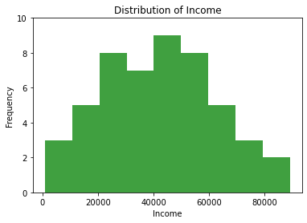

```python
#histogram of Income using 9 bins
n, bins, patches = plt.hist(vp.Income, 9, facecolor='green', alpha=0.75)
plt.ylim(0, 10)
plt.title('Distribution of Income')
plt.xlabel("Income")
plt.ylabel("Frequency")
plt.show()
```

```python
?plt.hist
```

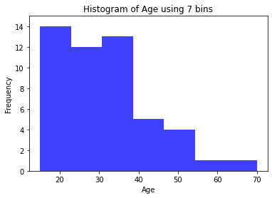

```python
#histogram of Age using 7 bins
n, bins, patches = plt.hist(vp.Age, 7, facecolor='blue', alpha=0.75)
plt.ylim(0, 15)
plt.xlabel("Age")
plt.ylabel("Frequency")
plt.title('Histogram of Age using 7 bins')
plt.show()
```

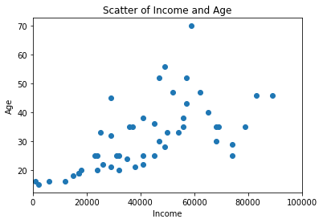

```python
plt.scatter(vp.Income,vp.Age)
plt.title('Scatter of Income and Age')
plt.xlabel("Income")
plt.ylabel("Age")
plt.xlim(0, 100000)
plt.show()
```

```python
#crosstab
video_cross=pd.crosstab(vp.Gender, vp.Genre,colnames=['Genre'],rownames=['Gender'])
print(video_cross)
```

```
Genre   Action  Comedy  Drama
Gender
F            5       6     13
M           13       6      7
```

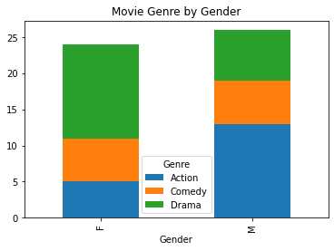

```python
#bar chart of Genre by Gender
video_cross.plot(kind='bar', stacked=True)
plt.title('Movie Genre by Gender')
```